# MovieLens Project Question Notebook

### `Project - MovieLens Data Analysis`

The GroupLens Research Project is a research group in the Department of Computer Science and Engineering at the University of Minnesota. The data is widely used for collaborative filtering and other filtering solutions. However, we will be using this data to act as a means to demonstrate our skill in using Python to “play” with data.

### `Objective:`

- To implement the techniques learnt as a part of the course.

### `Datasets Information:`

*rating.csv:* It contains information on ratings given by the users to a particular movie.

- user id: id assigned to every user
- movie id: id assigned to every movie
- rating: rating given by the user
- timestamp: Time recorded when the user gave a rating

*movie.csv:* File contains information related to the movies and their genre.

- movie id: id assigned to every movie
- movie title: Title of the movie
- release date: Date of release of the movie
- Action: Genre containing binary values (1 - for action 0 - not action)
- Adventure: Genre containing binary values (1 - for adventure 0 - not adventure)
- Animation: Genre containing binary values (1 - for animation 0 - not animation)
- Children’s: Genre containing binary values (1 - for children's 0 - not children's)
- Comedy: Genre containing binary values (1 - for comedy 0 - not comedy)
- Crime: Genre containing binary values (1 - for crime 0 - not crime)
- Documentary: Genre containing binary values (1 - for documentary 0 - not documentary)
- Drama: Genre containing binary values (1 - for drama 0 - not drama)
- Fantasy: Genre containing binary values (1 - for fantasy 0 - not fantasy)
- Film-Noir: Genre containing binary values (1 - for film-noir 0 - not film-noir)
- Horror: Genre containing binary values (1 - for horror 0 - not horror)
- Musical: Genre containing binary values (1 - for musical 0 - not musical)
- Mystery: Genre containing binary values (1 - for mystery 0 - not mystery)
- Romance: Genre containing binary values (1 - for romance 0 - not romance)
- Sci-Fi: Genre containing binary values (1 - for sci-fi 0 - not sci-fi)
- Thriller: Genre containing binary values (1 - for thriller 0 - not thriller)
- War: Genre containing binary values (1 - for war 0 - not war)
- Western: Genre containing binary values (1 - for western - not western)

*user.csv:* It contains information of the users who have rated the movies.

- user id: id assigned to every user
- age: Age of the user
- gender: Gender of the user
- occupation: Occupation of the user
- zip code: Zip code of the use

**`Please provide your insights wherever necessary.`**

### `Learning Outcomes:`

- Exploratory Data Analysis
- Visualization using Python
- Pandas – groupby, merging

### `Domain`

- Internet and Entertainment

**Note that the project will need you to apply the concepts of groupby and merging extensively.**

### 1. Import the necessary packages - 2.5 marks

```python
import numpy as np
import pandas as pd
import seaborn as sns
from matplotlib import pyplot as plt
import warnings
warnings.filterwarnings('ignore')   # to avoid warnings
```

### 2. Read the 3 datasets into dataframes - 2.5 marks

```python
rating = pd.read_csv('rating.csv')
# data.head(5)
# data.info()
movie = pd.read_csv('movie.csv')
# item.head(5)
# item.info()
user = pd.read_csv('user.csv')
# user.head(5)
# user.info(5)
```

### 3. Apply info, shape, describe, and find the number of missing values in the data. Present at least 3 observations from these operations - 2.5 marks

- Note that you will need to do it for all the three datasets seperately

```python
# Process rating.csv
print('*******Movie Rating Data Info*******')
print(rating.info())
print(rating.shape)
print(rating.columns)
# type(rating)
print(rating.describe())
# rating.isna().sum()
# print(rating.max() - rating.min())
# print(rating.std())
# print(rating.corr())
print(rating.isnull().sum())
```

```
*******Movie Rating Data Info*******
<class 'pandas.core.frame.DataFrame'>
RangeIndex: 100000 entries, 0 to 99999
Data columns (total 4 columns):
 #   Column     Non-Null Count   Dtype
---  ------     --------------   -----
 0   user id    100000 non-null  int64
 1   movie id   100000 non-null  int64
 2   rating     100000 non-null  int64
 3   timestamp  100000 non-null  int64
dtypes: int64(4)
memory usage: 3.1 MB
None
(100000, 4)
Index(['user id', 'movie id', 'rating', 'timestamp'], dtype='object')
            user id       movie id         rating     timestamp
count  100000.00000  100000.000000  100000.000000  1.000000e+05
mean      462.48475     425.530130       3.529860  8.835289e+08
std       266.61442     330.798356       1.125674  5.343856e+06
min         1.00000       1.000000       1.000000  8.747247e+08
25%       254.00000     175.000000       3.000000  8.794487e+08
50%       447.00000     322.000000       4.000000  8.828269e+08
75%       682.00000     631.000000       4.000000  8.882600e+08
max       943.00000    1682.000000       5.000000  8.932866e+08
user id      0
movie id     0
rating       0
timestamp    0
dtype: int64
```

### Observations:

1.For rating.csv data, all four attributes are int64 type. 2.For rating.csv data, there are no null values. 3.For rating.csv data, there are 100000 rows

```python
# Process movie.csv
print('*******Movie Data Info*******')
print(movie.info())
print(movie.shape)
print(movie.describe())
# print(movie.max() - rating.min())
# print(movie.std())
# print(movie.corr())
```

```
*******Movie Data Info*******
<class 'pandas.core.frame.DataFrame'>
RangeIndex: 1681 entries, 0 to 1680
Data columns (total 22 columns):
 #   Column        Non-Null Count  Dtype
---  ------        --------------  -----
 0   movie id      1681 non-null   int64
 1   movie title   1681 non-null   object
 2   release date  1681 non-null   object
 3   unknown       1681 non-null   int64
 4   Action        1681 non-null   int64
 5   Adventure     1681 non-null   int64
 6   Animation     1681 non-null   int64
 7   Childrens     1681 non-null   int64
 8   Comedy        1681 non-null   int64
 9   Crime         1681 non-null   int64
 10  Documentary   1681 non-null   int64
 11  Drama         1681 non-null   int64
 12  Fantasy       1681 non-null   int64
 13  Film-Noir     1681 non-null   int64
 14  Horror        1681 non-null   int64
 15  Musical       1681 non-null   int64
 16  Mystery       1681 non-null   int64
 17  Romance       1681 non-null   int64
 18  Sci-Fi        1681 non-null   int64
 19  Thriller      1681 non-null   int64
 20  War           1681 non-null   int64
 21  Western       1681 non-null   int64
dtypes: int64(20), object(2)
memory usage: 289.0+ KB
None
(1681, 22)
          movie id      unknown       Action    Adventure    Animation  \
count  1681.000000  1681.000000  1681.000000  1681.000000  1681.000000
mean    841.841761     0.000595     0.149316     0.080309     0.024985
std     485.638077     0.024390     0.356506     0.271852     0.156126
min       1.000000     0.000000     0.000000     0.000000     0.000000
25%     422.000000     0.000000     0.000000     0.000000     0.000000
50%     842.000000     0.000000     0.000000     0.000000     0.000000
75%    1262.000000     0.000000     0.000000     0.000000     0.000000
```

[output cut: 16 more lines]

```
min       0.000000     0.000000     0.000000     0.000000     0.000000
25%       0.000000     0.000000     0.000000     0.000000     0.000000
50%       0.000000     0.000000     0.000000     0.000000     0.000000
75%       0.000000     0.000000     0.000000     0.000000     0.000000
max       1.000000     1.000000     1.000000     1.000000     1.000000

           Romance       Sci-Fi     Thriller          War      Western
count  1681.000000  1681.000000  1681.000000  1681.000000  1681.000000
mean      0.146936     0.060083     0.149316     0.042237     0.016062
std       0.354148     0.237712     0.356506     0.201189     0.125751
min       0.000000     0.000000     0.000000     0.000000     0.000000
25%       0.000000     0.000000     0.000000     0.000000     0.000000
50%       0.000000     0.000000     0.000000     0.000000     0.000000
75%       0.000000     0.000000     0.000000     0.000000     0.000000
max       1.000000     1.000000     1.000000     1.000000     1.000000
```

### Observations:

1.For movie.csv data, there are no null values. 2.There is only one movie in unknown category 3.For movie.csv data, there are 1681 rows

```python
# Process user.csv
print('*******User Data Info*******')
print(user.info())
print(user.shape)
# user.columns
print(user.describe())
# print(user.max() - user.min())
# print(user.std())
# print(user.corr())
```

```
*******User Data Info*******
<class 'pandas.core.frame.DataFrame'>
RangeIndex: 943 entries, 0 to 942
Data columns (total 5 columns):
 #   Column      Non-Null Count  Dtype
---  ------      --------------  -----
 0   user id     943 non-null    int64
 1   age         943 non-null    int64
 2   gender      943 non-null    object
 3   occupation  943 non-null    object
 4   zip code    943 non-null    object
dtypes: int64(2), object(3)
memory usage: 37.0+ KB
None
(943, 5)
          user id         age
count  943.000000  943.000000
mean   472.000000   34.051962
std    272.364951   12.192740
min      1.000000    7.000000
25%    236.500000   25.000000
50%    472.000000   31.000000
75%    707.500000   43.000000
max    943.000000   73.000000
```

### Observations:

1.Userid is common field between user.csv & rating.csv 2.Min age of a user is 7 and max age is 73 3.For user.csv data, there are 943 rows

### 4. Find the number of movies per genre using the item data - 2.5 marks

```python
movies_per_genre = pd.DataFrame(movie,columns=['unknown','Action','Adventure','Animation','Childrens','Comedy','Crime','Documentary','Drama','Fantasy','Film-Noir','Horror','Musical','Mystery','Romance','Sci-Fi','Thriller','War','Western'])
movies_per_genre_sum= movies_per_genre.sum(axis=0)
print (movies_per_genre_sum)
```

```
unknown          1
Action         251
Adventure      135
Animation       42
Childrens      122
Comedy         505
Crime          109
Documentary     50
Drama          725
Fantasy         22
Film-Noir       24
Horror          92
Musical         56
Mystery         61
Romance        247
Sci-Fi         101
Thriller       251
War             71
Western         27
dtype: int64
```

**Insights:**

Drama has max (725) followed by Comedy (505)

### 5. Drop the movie where the genre is unknown - 2.5 marks

```python
# indexVal = movie[ movie['unknown'] == 1 ].index
# print(indexVal)
# movie.drop(indexVal , inplace=True)
movie.drop( movie[ movie['unknown'] == 1 ].index , inplace=False)
```

|  | movie id | movie title | release date | unknown | Action | Adventure | Animation | Childrens | Comedy | Crime | ... | Fantasy | Film-Noir | Horror | Musical | Mystery | Romance | Sci-Fi | Thriller | War | Western |
| --- | --- | --- | --- | --- | --- | --- | --- | --- | --- | --- | --- | --- | --- | --- | --- | --- | --- | --- | --- | --- | --- |
| 0 | 1 | Toy Story | 01-Jan-1995 | 0 | 0 | 0 | 1 | 1 | 1 | 0 | ... | 0 | 0 | 0 | 0 | 0 | 0 | 0 | 0 | 0 | 0 |
| 1 | 2 | GoldenEye | 01-Jan-1995 | 0 | 1 | 1 | 0 | 0 | 0 | 0 | ... | 0 | 0 | 0 | 0 | 0 | 0 | 0 | 1 | 0 | 0 |
| 2 | 3 | Four Rooms | 01-Jan-1995 | 0 | 0 | 0 | 0 | 0 | 0 | 0 | ... | 0 | 0 | 0 | 0 | 0 | 0 | 0 | 1 | 0 | 0 |
| 3 | 4 | Get Shorty | 01-Jan-1995 | 0 | 1 | 0 | 0 | 0 | 1 | 0 | ... | 0 | 0 | 0 | 0 | 0 | 0 | 0 | 0 | 0 | 0 |
| 4 | 5 | Copycat | 01-Jan-1995 | 0 | 0 | 0 | 0 | 0 | 0 | 1 | ... | 0 | 0 | 0 | 0 | 0 | 0 | 0 | 1 | 0 | 0 |
| ... | ... | ... | ... | ... | ... | ... | ... | ... | ... | ... | ... | ... | ... | ... | ... | ... | ... | ... | ... | ... | ... |
| 1676 | 1678 | Mat' i syn | 06-Feb-1998 | 0 | 0 | 0 | 0 | 0 | 0 | 0 | ... | 0 | 0 | 0 | 0 | 0 | 0 | 0 | 0 | 0 | 0 |
| 1677 | 1679 | B. Monkey | 06-Feb-1998 | 0 | 0 | 0 | 0 | 0 | 0 | 0 | ... | 0 | 0 | 0 | 0 | 0 | 1 | 0 | 1 | 0 | 0 |
| 1678 | 1680 | Sliding Doors | 01-Jan-1998 | 0 | 0 | 0 | 0 | 0 | 0 | 0 | ... | 0 | 0 | 0 | 0 | 0 | 1 | 0 | 0 | 0 | 0 |
| 1679 | 1681 | You So Crazy | 01-Jan-1994 | 0 | 0 | 0 | 0 | 0 | 1 | 0 | ... | 0 | 0 | 0 | 0 | 0 | 0 | 0 | 0 | 0 | 0 |
| 1680 | 1682 | Scream of Stone (Schrei aus Stein) | 08-Mar-1996 | 0 | 0 | 0 | 0 | 0 | 0 | 0 | ... | 0 | 0 | 0 | 0 | 0 | 0 | 0 | 0 | 0 | 0 |

1680 rows × 22 columns

**Insights:** There is only 1 record with 'unknown genre'

### 6. Find the movies that have more than one genre - 5 marks

hint: use sum on the axis = 1

Display movie name, number of genres for the movie in dataframe

and also print(total number of movies which have more than one genres)

```python
 # movies_genre = pd.DataFrame(movie,columns=['unknown','Action','Adventure','Animation','Childrens','Comedy','Crime','Documentary','Drama','Fantasy','Film-Noir','Horror','Musical','Mystery','Romance','Sci-Fi','Thriller','War','Western'])
 # print(movies_genre.sum(axis=1))
movie.columns
```

```
Index(['movie id', 'movie title', 'release date', 'unknown', 'Action',
       'Adventure', 'Animation', 'Childrens', 'Comedy', 'Crime', 'Documentary',
       'Drama', 'Fantasy', 'Film-Noir', 'Horror', 'Musical', 'Mystery',
       'Romance', 'Sci-Fi', 'Thriller', 'War', 'Western'],
      dtype='object')
```

```python
item_movie = movie [['movie id','movie title']]
item_movie ["Genres"] = movie.loc[:,'Action':'Western'].sum (axis=1)
item_movie [item_movie["Genres"]>1]
```

|  | movie id | movie title | Genres |
| --- | --- | --- | --- |
| 0 | 1 | Toy Story | 3 |
| 1 | 2 | GoldenEye | 3 |
| 3 | 4 | Get Shorty | 3 |
| 4 | 5 | Copycat | 3 |
| 6 | 7 | Twelve Monkeys | 2 |
| ... | ... | ... | ... |
| 1667 | 1669 | MURDER and murder | 3 |
| 1668 | 1670 | Tainted | 2 |
| 1671 | 1673 | Mirage | 2 |
| 1677 | 1679 | B. Monkey | 2 |
| 1678 | 1680 | Sliding Doors | 2 |

849 rows × 3 columns

**Insights:**

849 movies have more than one genre

### 7. Univariate plots of columns: 'rating', 'Age', 'release year', 'Gender' and 'Occupation' - 10 marks

*HINT: Use distplot for age and countplot for release year, ratings,*

*HINT: Please refer to the below snippet to understand how to get to release year from release date. You can use str.split() as depicted below or you could convert it to pandas datetime format and extract year (.dt.year)*

```python
a = 'My*cat*is*brown'
print(a.split('*')[3])

#similarly, the release year needs to be taken out from release date

#also you can simply slice existing string to get the desired data, if we want to take out the colour of the cat

print(a[10:])
print(a[-5:])
```

```
brown
brown
brown
```

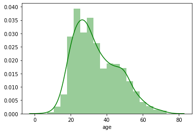

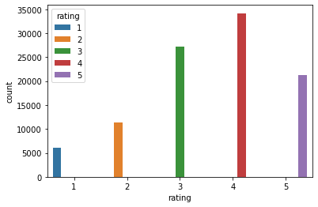

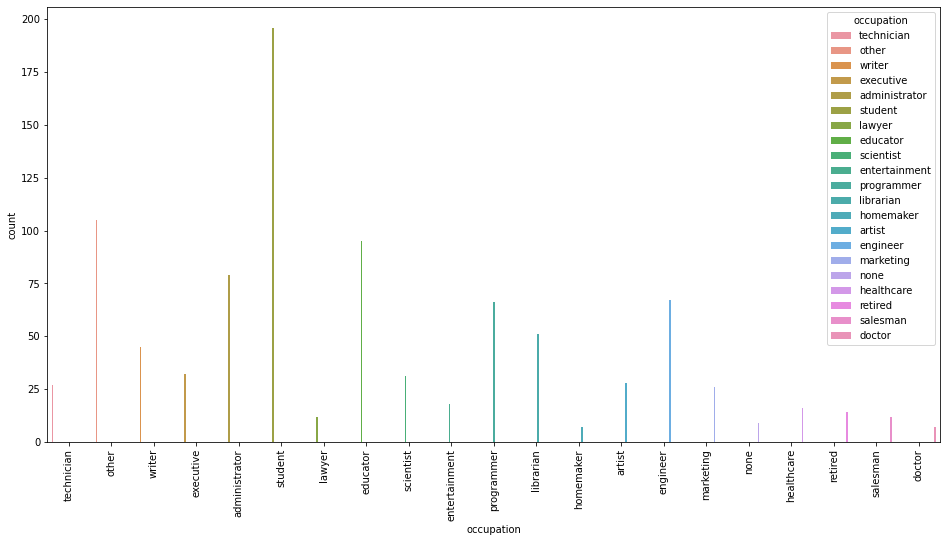

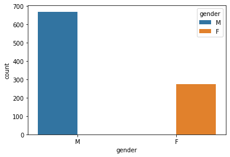

```python
sns.distplot(user ['age'],color='green')
plt.show()
sns.countplot(rating ['rating'], hue = rating ['rating'])
plt.show()
plt.figure(figsize = (16,8))
plt.xticks (rotation = 90)
sns.countplot(user ['occupation'], hue = user ['occupation'] )
plt.show()
sns.countplot(user ['gender'], hue = user ['gender'] )
plt.show()
```

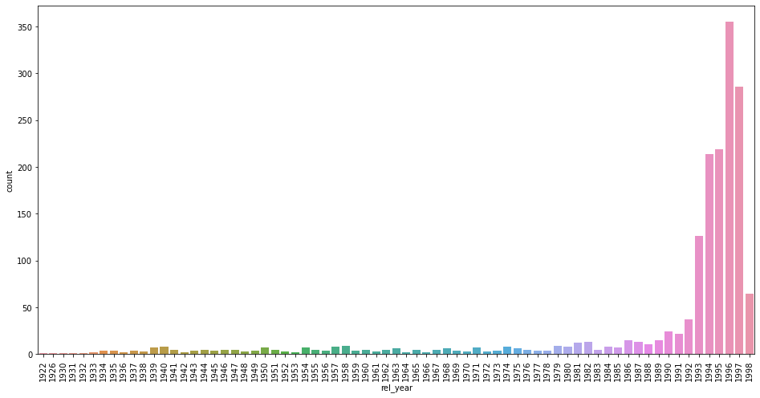

```python
movie ['release_yr'] = pd.to_datetime(movie['release date'])
movie ['rel_year'] = movie ['release_yr'].apply(lambda x: x.year)
movie.head()

plt.figure(figsize = (16,8))
plt.xticks (rotation = 90)
sns.countplot(x = movie ['rel_year'])
plt.show()

#movie.drop(['release_yr','rel_year'],axis=1,inplace=True)
#movie.head()
```

**Insights:**

1. People between ages 20~40 watch more movies
2. Students (occupation category) watches more movies
3. Male watch more movies than Female

### 8. Visualize how popularity of genres has changed over the years - 10 marks

Note that you need to use the **percent of number of releases in a year** as a parameter of popularity of a genre

Hint 1: You need to reach to a data frame where the release year is the index and the genre is the column names (one cell shows the number of release in a year in one genre) or vice versa. (Drop unnecessary column if there are any)

Hint 2: Find the total number of movies release in a year(use item dataset to get count of movies released in a particular year, store that value in a new column as 'total'). Now divide the value of each genre in that year by total to get percentage number of release in a particular year. `(df.div(df['total'], axis= 0) * 100)`

Once that is achieved, you can either use univariate plots or can use the heatmap to visualise all the changes over the years in one go.

Hint 3: Use groupby on the relevant column and use sum() on the same to find out the number of releases in a year/genre.

```python
yr_genre = movie.groupby('rel_year').sum()
yr_genre = yr_genre.drop(columns = 'movie id')
yr_genre
```

| rel_year | unknown | Action | Adventure | Animation | Childrens | Comedy | Crime | Documentary | Drama | Fantasy | Film-Noir | Horror | Musical | Mystery | Romance | Sci-Fi | Thriller | War | Western |
| --- | --- | --- | --- | --- | --- | --- | --- | --- | --- | --- | --- | --- | --- | --- | --- | --- | --- | --- | --- |
| 1922 | 0 | 0 | 0 | 0 | 0 | 0 | 0 | 0 | 0 | 0 | 0 | 1 | 0 | 0 | 0 | 0 | 0 | 0 | 0 |
| 1926 | 0 | 0 | 0 | 0 | 0 | 0 | 0 | 0 | 1 | 0 | 0 | 0 | 0 | 0 | 0 | 0 | 0 | 0 | 0 |
| 1930 | 0 | 0 | 0 | 0 | 0 | 0 | 0 | 0 | 1 | 0 | 0 | 0 | 0 | 0 | 0 | 0 | 0 | 0 | 0 |
| 1931 | 0 | 0 | 0 | 0 | 0 | 0 | 1 | 0 | 0 | 0 | 1 | 0 | 0 | 0 | 0 | 0 | 1 | 0 | 0 |
| 1932 | 0 | 0 | 0 | 0 | 0 | 0 | 0 | 0 | 0 | 0 | 0 | 0 | 0 | 0 | 1 | 0 | 0 | 1 | 0 |
| ... | ... | ... | ... | ... | ... | ... | ... | ... | ... | ... | ... | ... | ... | ... | ... | ... | ... | ... | ... |
| 1994 | 0 | 30 | 13 | 4 | 15 | 82 | 8 | 9 | 97 | 3 | 0 | 8 | 2 | 2 | 35 | 7 | 25 | 7 | 6 |
| 1995 | 0 | 40 | 22 | 6 | 21 | 63 | 11 | 5 | 89 | 3 | 1 | 14 | 3 | 5 | 37 | 15 | 39 | 5 | 2 |
| 1996 | 0 | 44 | 24 | 9 | 21 | 108 | 21 | 18 | 170 | 6 | 1 | 11 | 9 | 6 | 38 | 15 | 47 | 9 | 2 |
| 1997 | 0 | 46 | 20 | 3 | 22 | 87 | 30 | 6 | 113 | 4 | 2 | 8 | 5 | 18 | 51 | 13 | 54 | 14 | 0 |
| 1998 | 0 | 12 | 3 | 0 | 1 | 13 | 7 | 3 | 33 | 1 | 2 | 4 | 1 | 3 | 11 | 5 | 18 | 0 | 0 |

71 rows × 19 columns

```python
cnt_movie = movie.groupby('rel_year')['movie id'].count().reset_index().rename(columns={'movie id':'Total'}).set_index('rel_year')
#yr_genre.join(cnt_movie)
yr_genre = yr_genre.join (cnt_movie)
```

```python
yr_genre
```

| rel_year | unknown | Action | Adventure | Animation | Childrens | Comedy | Crime | Documentary | Drama | Fantasy | Film-Noir | Horror | Musical | Mystery | Romance | Sci-Fi | Thriller | War | Western | Total |
| --- | --- | --- | --- | --- | --- | --- | --- | --- | --- | --- | --- | --- | --- | --- | --- | --- | --- | --- | --- | --- |
| 1922 | 0 | 0 | 0 | 0 | 0 | 0 | 0 | 0 | 0 | 0 | 0 | 1 | 0 | 0 | 0 | 0 | 0 | 0 | 0 | 1 |
| 1926 | 0 | 0 | 0 | 0 | 0 | 0 | 0 | 0 | 1 | 0 | 0 | 0 | 0 | 0 | 0 | 0 | 0 | 0 | 0 | 1 |
| 1930 | 0 | 0 | 0 | 0 | 0 | 0 | 0 | 0 | 1 | 0 | 0 | 0 | 0 | 0 | 0 | 0 | 0 | 0 | 0 | 1 |
| 1931 | 0 | 0 | 0 | 0 | 0 | 0 | 1 | 0 | 0 | 0 | 1 | 0 | 0 | 0 | 0 | 0 | 1 | 0 | 0 | 1 |
| 1932 | 0 | 0 | 0 | 0 | 0 | 0 | 0 | 0 | 0 | 0 | 0 | 0 | 0 | 0 | 1 | 0 | 0 | 1 | 0 | 1 |
| ... | ... | ... | ... | ... | ... | ... | ... | ... | ... | ... | ... | ... | ... | ... | ... | ... | ... | ... | ... | ... |
| 1994 | 0 | 30 | 13 | 4 | 15 | 82 | 8 | 9 | 97 | 3 | 0 | 8 | 2 | 2 | 35 | 7 | 25 | 7 | 6 | 214 |
| 1995 | 0 | 40 | 22 | 6 | 21 | 63 | 11 | 5 | 89 | 3 | 1 | 14 | 3 | 5 | 37 | 15 | 39 | 5 | 2 | 219 |
| 1996 | 0 | 44 | 24 | 9 | 21 | 108 | 21 | 18 | 170 | 6 | 1 | 11 | 9 | 6 | 38 | 15 | 47 | 9 | 2 | 355 |
| 1997 | 0 | 46 | 20 | 3 | 22 | 87 | 30 | 6 | 113 | 4 | 2 | 8 | 5 | 18 | 51 | 13 | 54 | 14 | 0 | 286 |
| 1998 | 0 | 12 | 3 | 0 | 1 | 13 | 7 | 3 | 33 | 1 | 2 | 4 | 1 | 3 | 11 | 5 | 18 | 0 | 0 | 65 |

71 rows × 20 columns

```python
yr_genre = (yr_genre.div(yr_genre['Total'],axis = 0) * 100).drop('Total',axis=1).T
yr_genre
```

| rel_year | 1922 | 1926 | 1930 | 1931 | 1932 | 1933 | 1934 | 1935 | 1936 | 1937 | ... | 1989 | 1990 | 1991 | 1992 | 1993 | 1994 | 1995 | 1996 | 1997 | 1998 |
| --- | --- | --- | --- | --- | --- | --- | --- | --- | --- | --- | --- | --- | --- | --- | --- | --- | --- | --- | --- | --- | --- |
| unknown | 0.0 | 0.0 | 0.0 | 0.0 | 0.0 | 0.0 | 0.0 | 0.0 | 0.0 | 0.0 | ... | 0.000000 | 0.000000 | 0.000000 | 0.000000 | 0.000000 | 0.000000 | 0.000000 | 0.000000 | 0.000000 | 0.000000 |
| Action | 0.0 | 0.0 | 0.0 | 0.0 | 0.0 | 0.0 | 0.0 | 0.0 | 0.0 | 0.0 | ... | 40.000000 | 29.166667 | 9.090909 | 21.621622 | 15.873016 | 14.018692 | 18.264840 | 12.394366 | 16.083916 | 18.461538 |
| Adventure | 0.0 | 0.0 | 0.0 | 0.0 | 0.0 | 0.0 | 0.0 | 0.0 | 0.0 | 0.0 | ... | 26.666667 | 4.166667 | 4.545455 | 2.702703 | 7.142857 | 6.074766 | 10.045662 | 6.760563 | 6.993007 | 4.615385 |
| Animation | 0.0 | 0.0 | 0.0 | 0.0 | 0.0 | 0.0 | 0.0 | 0.0 | 0.0 | 25.0 | ... | 0.000000 | 0.000000 | 4.545455 | 5.405405 | 0.793651 | 1.869159 | 2.739726 | 2.535211 | 1.048951 | 0.000000 |
| Childrens | 0.0 | 0.0 | 0.0 | 0.0 | 0.0 | 0.0 | 0.0 | 0.0 | 0.0 | 25.0 | ... | 0.000000 | 4.166667 | 4.545455 | 2.702703 | 4.761905 | 7.009346 | 9.589041 | 5.915493 | 7.692308 | 1.538462 |
| Comedy | 0.0 | 0.0 | 0.0 | 0.0 | 0.0 | 50.0 | 50.0 | 50.0 | 50.0 | 50.0 | ... | 20.000000 | 25.000000 | 27.272727 | 32.432432 | 30.952381 | 38.317757 | 28.767123 | 30.422535 | 30.419580 | 20.000000 |
| Crime | 0.0 | 0.0 | 0.0 | 100.0 | 0.0 | 0.0 | 0.0 | 0.0 | 0.0 | 0.0 | ... | 6.666667 | 12.500000 | 0.000000 | 13.513514 | 5.555556 | 3.738318 | 5.022831 | 5.915493 | 10.489510 | 10.769231 |
| Documentary | 0.0 | 0.0 | 0.0 | 0.0 | 0.0 | 0.0 | 0.0 | 0.0 | 0.0 | 0.0 | ... | 0.000000 | 8.333333 | 4.545455 | 0.000000 | 3.174603 | 4.205607 | 2.283105 | 5.070423 | 2.097902 | 4.615385 |
| Drama | 0.0 | 100.0 | 100.0 | 0.0 | 0.0 | 0.0 | 25.0 | 0.0 | 50.0 | 25.0 | ... | 53.333333 | 50.000000 | 50.000000 | 37.837838 | 50.793651 | 45.327103 | 40.639269 | 47.887324 | 39.510490 | 50.769231 |
| Fantasy | 0.0 | 0.0 | 0.0 | 0.0 | 0.0 | 0.0 | 0.0 | 0.0 | 0.0 | 0.0 | ... | 0.000000 | 0.000000 | 4.545455 | 0.000000 | 0.000000 | 1.401869 | 1.369863 | 1.690141 | 1.398601 | 1.538462 |
| Film-Noir | 0.0 | 0.0 | 0.0 | 100.0 | 0.0 | 0.0 | 0.0 | 0.0 | 0.0 | 0.0 | ... | 0.000000 | 4.166667 | 0.000000 | 0.000000 | 0.793651 | 0.000000 | 0.456621 | 0.281690 | 0.699301 | 3.076923 |
| Horror | 100.0 | 0.0 | 0.0 | 0.0 | 0.0 | 0.0 | 0.0 | 25.0 | 0.0 | 0.0 | ... | 0.000000 | 4.166667 | 4.545455 | 16.216216 | 3.968254 | 3.738318 | 6.392694 | 3.098592 | 2.797203 | 6.153846 |
| Musical | 0.0 | 0.0 | 0.0 | 0.0 | 0.0 | 0.0 | 25.0 | 25.0 | 0.0 | 75.0 | ... | 0.000000 | 0.000000 | 9.090909 | 2.702703 | 1.587302 | 0.934579 | 1.369863 | 2.535211 | 1.748252 | 1.538462 |
| Mystery | 0.0 | 0.0 | 0.0 | 0.0 | 0.0 | 0.0 | 25.0 | 0.0 | 0.0 | 0.0 | ... | 0.000000 | 0.000000 | 0.000000 | 2.702703 | 4.761905 | 0.934579 | 2.283105 | 1.690141 | 6.293706 | 4.615385 |
| Romance | 0.0 | 0.0 | 0.0 | 0.0 | 100.0 | 50.0 | 25.0 | 25.0 | 0.0 | 50.0 | ... | 6.666667 | 16.666667 | 0.000000 | 18.918919 | 12.698413 | 16.355140 | 16.894977 | 10.704225 | 17.832168 | 16.923077 |
| Sci-Fi | 0.0 | 0.0 | 0.0 | 0.0 | 0.0 | 0.0 | 0.0 | 0.0 | 0.0 | 0.0 | ... | 13.333333 | 0.000000 | 18.181818 | 8.108108 | 6.349206 | 3.271028 | 6.849315 | 4.225352 | 4.545455 | 7.692308 |
| Thriller | 0.0 | 0.0 | 0.0 | 100.0 | 0.0 | 0.0 | 0.0 | 25.0 | 0.0 | 0.0 | ... | 13.333333 | 16.666667 | 13.636364 | 13.513514 | 13.492063 | 11.682243 | 17.808219 | 13.239437 | 18.881119 | 27.692308 |
| War | 0.0 | 0.0 | 0.0 | 0.0 | 100.0 | 50.0 | 0.0 | 0.0 | 0.0 | 0.0 | ... | 13.333333 | 0.000000 | 4.545455 | 5.405405 | 3.174603 | 3.271028 | 2.283105 | 2.535211 | 4.895105 | 0.000000 |
| Western | 0.0 | 0.0 | 0.0 | 0.0 | 0.0 | 0.0 | 0.0 | 0.0 | 0.0 | 0.0 | ... | 0.000000 | 8.333333 | 0.000000 | 2.702703 | 1.587302 | 2.803738 | 0.913242 | 0.563380 | 0.000000 | 0.000000 |

19 rows × 71 columns

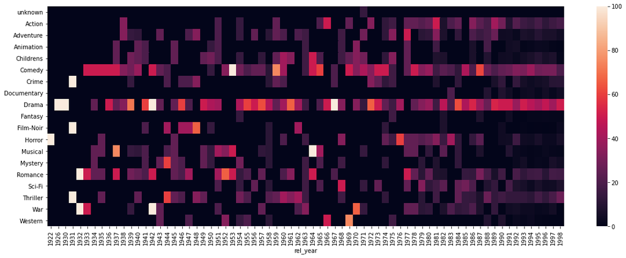

```python
plt.figure(figsize=(20,7))
sns.heatmap(yr_genre)
plt.show()
```

Hints :

1. Find the count of ratings and average ratings for every movie.
2. Slice the movies which have ratings more than 100.
3. Sort values according to average rating such that movie which highest rating is on top.
4. Select top 25 movies.
5. You will have to use the .merge() function to get the movie titles.

Note: This question will need you to research about groupby and apply your findings. You can find more on groupby on https://realpython.com/pandas-groupby/.

```python
movie_dat = rating.groupby('movie id')['rating'].agg(['count','mean'])
movie_dat.head()
```

| movie id | count | mean |
| --- | --- | --- |
| 1 | 452 | 3.878319 |
| 2 | 131 | 3.206107 |
| 3 | 90 | 3.033333 |
| 4 | 209 | 3.550239 |
| 5 | 86 | 3.302326 |

```python
movie_dat = movie_dat[movie_dat['count'] > 100]
movie_dat.head()
```

| movie id | count | mean |
| --- | --- | --- |
| 1 | 452 | 3.878319 |
| 2 | 131 | 3.206107 |
| 4 | 209 | 3.550239 |
| 7 | 392 | 3.798469 |
| 8 | 219 | 3.995434 |

```python
#movie_dat.merge(movie[['movie id','movie title']],on='movie id').head(25)
movie_dat.merge(movie[['movie id','movie title']],on='movie id',how='left').head(25)
```

|  | movie id | count | mean | movie title |
| --- | --- | --- | --- | --- |
| 0 | 1 | 452 | 3.878319 | Toy Story |
| 1 | 2 | 131 | 3.206107 | GoldenEye |
| 2 | 4 | 209 | 3.550239 | Get Shorty |
| 3 | 7 | 392 | 3.798469 | Twelve Monkeys |
| 4 | 8 | 219 | 3.995434 | Babe |
| 5 | 9 | 299 | 3.896321 | Dead Man Walking |
| 6 | 11 | 236 | 3.847458 | Seven (Se7en) |
| 7 | 12 | 267 | 4.385768 | Usual Suspects, The |
| 8 | 13 | 184 | 3.418478 | Mighty Aphrodite |
| 9 | 14 | 183 | 3.967213 | Postino, Il |
| 10 | 15 | 293 | 3.778157 | Mr. Holland's Opus |
| 11 | 22 | 297 | 4.151515 | Braveheart |
| 12 | 23 | 182 | 4.120879 | Taxi Driver |
| 13 | 24 | 174 | 3.448276 | Rumble in the Bronx |
| 14 | 25 | 293 | 3.443686 | Birdcage, The |
| 15 | 28 | 276 | 3.931159 | Apollo 13 |
| 16 | 29 | 114 | 2.666667 | Batman Forever |
| 17 | 31 | 154 | 3.629870 | Crimson Tide |
| 18 | 38 | 120 | 3.008333 | Net, The |
| 19 | 42 | 148 | 3.804054 | Clerks |
| 20 | 47 | 133 | 3.601504 | Ed Wood |
| 21 | 48 | 117 | 4.094017 | Hoop Dreams |
| 22 | 50 | 583 | 4.358491 | Star Wars |
| 23 | 53 | 128 | 2.953125 | Natural Born Killers |
| 24 | 54 | 104 | 3.240385 | Outbreak |

### 10. Check for the validity of the below statements with respect to the data provided - 10 marks

- Men watch more drama than women
- Women watch more Sci-Fi than men
- Men watch more Romance than women

**compare the percentages**

**Please pay attention to what should be the denominator while calculating percentages**

1. Merge all the datasets
2. There is no need to conduct statistical tests around this. Just **compare the percentages** and comment on the validity of the above statements.
3. you might want ot use the .sum(), .div() function here.
4. Use number of ratings to validate the numbers. For example, if out of 4000 ratings received by women, 3000 are for drama, we will assume that 75% of the women watch drama.

```python
usr_dat = user.merge(rating,on='user id',how='inner')
mov_dat = movie.merge(usr_dat,on='movie id',how='inner')
mov_dat.head()
```

|  | movie id | movie title | release date | unknown | Action | Adventure | Animation | Childrens | Comedy | Crime | ... | Western | release_yr | rel_year | user id | age | gender | occupation | zip code | rating | timestamp |
| --- | --- | --- | --- | --- | --- | --- | --- | --- | --- | --- | --- | --- | --- | --- | --- | --- | --- | --- | --- | --- | --- |
| 0 | 1 | Toy Story | 01-Jan-1995 | 0 | 0 | 0 | 1 | 1 | 1 | 0 | ... | 0 | 1995-01-01 | 1995 | 1 | 24 | M | technician | 85711 | 5 | 874965758 |
| 1 | 1 | Toy Story | 01-Jan-1995 | 0 | 0 | 0 | 1 | 1 | 1 | 0 | ... | 0 | 1995-01-01 | 1995 | 2 | 53 | F | other | 94043 | 4 | 888550871 |
| 2 | 1 | Toy Story | 01-Jan-1995 | 0 | 0 | 0 | 1 | 1 | 1 | 0 | ... | 0 | 1995-01-01 | 1995 | 5 | 33 | F | other | 15213 | 4 | 875635748 |
| 3 | 1 | Toy Story | 01-Jan-1995 | 0 | 0 | 0 | 1 | 1 | 1 | 0 | ... | 0 | 1995-01-01 | 1995 | 6 | 42 | M | executive | 98101 | 4 | 883599478 |
| 4 | 1 | Toy Story | 01-Jan-1995 | 0 | 0 | 0 | 1 | 1 | 1 | 0 | ... | 0 | 1995-01-01 | 1995 | 10 | 53 | M | lawyer | 90703 | 4 | 877888877 |

5 rows × 31 columns

```python
genre_per_gender = mov_dat.groupby('gender').sum().loc[:,'Action':'Western']
genre_per_gender
```

| gender | Action | Adventure | Animation | Childrens | Comedy | Crime | Documentary | Drama | Fantasy | Film-Noir | Horror | Musical | Mystery | Romance | Sci-Fi | Thriller | War | Western |
| --- | --- | --- | --- | --- | --- | --- | --- | --- | --- | --- | --- | --- | --- | --- | --- | --- | --- | --- |
| F | 5442 | 3141 | 995 | 2232 | 8068 | 1794 | 187 | 11008 | 363 | 385 | 1197 | 1442 | 1314 | 5858 | 2629 | 5086 | 2189 | 371 |
| M | 20147 | 10612 | 2610 | 4950 | 21764 | 6261 | 571 | 28887 | 989 | 1348 | 4120 | 3512 | 3931 | 13603 | 10101 | 16786 | 7209 | 1483 |